# Optimal Treatment Analysis

## Outcome Variable

**Outcome Variable:** whz

## Predictor Variables

**Intervention Variable:** gagebrth

**Adjustment Set:**

- arm
- sex
- W_mage
- meducyrs
- feducyrs
- hhwealth_quart
- single
- brthmon
- W_parity
- delta_W_mage
- delta_meducyrs
- delta_feducyrs
- delta_hhwealth_quart
- delta_single
- delta_brthmon
- delta_W_parity

## Stratifying Variables

The analysis was stratified on these variable(s):

- agecat
- studyid
- country

## Data Summary

| agecat | studyid | country | gagebrth | n_cell | n |
| --- | --- | --- | --- | --- | --- |
| Birth | ki1000108-CMC-V-BCS-2002 | INDIA | Full or late term | 54 | 87 |
| Birth | ki1000108-CMC-V-BCS-2002 | INDIA | Preterm | 10 | 87 |
| Birth | ki1000108-CMC-V-BCS-2002 | INDIA | Early term | 23 | 87 |
| Birth | ki1000108-IRC | INDIA | Full or late term | 213 | 328 |
| Birth | ki1000108-IRC | INDIA | Preterm | 32 | 328 |
| Birth | ki1000108-IRC | INDIA | Early term | 83 | 328 |
| Birth | ki1000109-EE | PAKISTAN | Full or late term | 0 | 1 |
| Birth | ki1000109-EE | PAKISTAN | Preterm | 1 | 1 |
| Birth | ki1000109-EE | PAKISTAN | Early term | 0 | 1 |
| Birth | ki1000304b-SAS-CompFeed | INDIA | Full or late term | 1 | 166 |
| Birth | ki1000304b-SAS-CompFeed | INDIA | Preterm | 151 | 166 |
| Birth | ki1000304b-SAS-CompFeed | INDIA | Early term | 14 | 166 |
| Birth | ki1017093c-NIH-Crypto | BANGLADESH | Full or late term | 6 | 23 |
| Birth | ki1017093c-NIH-Crypto | BANGLADESH | Preterm | 3 | 23 |
| Birth | ki1017093c-NIH-Crypto | BANGLADESH | Early term | 14 | 23 |
| Birth | ki1101329-Keneba | GAMBIA | Full or late term | 680 | 1401 |
| Birth | ki1101329-Keneba | GAMBIA | Preterm | 207 | 1401 |
| Birth | ki1101329-Keneba | GAMBIA | Early term | 514 | 1401 |
| Birth | ki1119695-PROBIT | BELARUS | Full or late term | 7071 | 13824 |
| Birth | ki1119695-PROBIT | BELARUS | Preterm | 468 | 13824 |
| Birth | ki1119695-PROBIT | BELARUS | Early term | 6285 | 13824 |
| Birth | ki1135781-COHORTS | GUATEMALA | Full or late term | 323 | 572 |
| Birth | ki1135781-COHORTS | GUATEMALA | Preterm | 78 | 572 |
| Birth | ki1135781-COHORTS | GUATEMALA | Early term | 171 | 572 |
| Birth | ki1135781-COHORTS | INDIA | Full or late term | 553 | 1229 |
| Birth | ki1135781-COHORTS | INDIA | Preterm | 259 | 1229 |
| Birth | ki1135781-COHORTS | INDIA | Early term | 417 | 1229 |
| Birth | ki1135781-COHORTS | PHILIPPINES | Full or late term | 1135 | 2874 |
| Birth | ki1135781-COHORTS | PHILIPPINES | Preterm | 579 | 2874 |
| Birth | ki1135781-COHORTS | PHILIPPINES | Early term | 1160 | 2874 |

[output cut: 69 more lines]

The following strata were considered:

- agecat: 24 months, studyid: ki1000108-CMC-V-BCS-2002, country: INDIA
- agecat: 24 months, studyid: ki1000108-IRC, country: INDIA
- agecat: 24 months, studyid: ki1017093c-NIH-Crypto, country: BANGLADESH
- agecat: 24 months, studyid: ki1066203-TanzaniaChild2, country: TANZANIA, UNITED REPUBLIC OF
- agecat: 24 months, studyid: ki1101329-Keneba, country: GAMBIA
- agecat: 24 months, studyid: ki1119695-PROBIT, country: BELARUS
- agecat: 24 months, studyid: ki1135781-COHORTS, country: GUATEMALA
- agecat: 24 months, studyid: ki1135781-COHORTS, country: INDIA
- agecat: 24 months, studyid: ki1135781-COHORTS, country: PHILIPPINES
- agecat: 24 months, studyid: kiGH5241-JiVitA-3, country: BANGLADESH
- agecat: 6 months, studyid: ki1000108-CMC-V-BCS-2002, country: INDIA
- agecat: 6 months, studyid: ki1000108-IRC, country: INDIA
- agecat: 6 months, studyid: ki1000109-EE, country: PAKISTAN
- agecat: 6 months, studyid: ki1000304b-SAS-CompFeed, country: INDIA
- agecat: 6 months, studyid: ki1017093c-NIH-Crypto, country: BANGLADESH
- agecat: 6 months, studyid: ki1066203-TanzaniaChild2, country: TANZANIA, UNITED REPUBLIC OF
- agecat: 6 months, studyid: ki1101329-Keneba, country: GAMBIA
- agecat: 6 months, studyid: ki1119695-PROBIT, country: BELARUS
- agecat: 6 months, studyid: ki1135781-COHORTS, country: GUATEMALA
- agecat: 6 months, studyid: ki1135781-COHORTS, country: INDIA
- agecat: 6 months, studyid: ki1135781-COHORTS, country: PHILIPPINES
- agecat: 6 months, studyid: kiGH5241-JiVitA-3, country: BANGLADESH
- agecat: Birth, studyid: ki1000108-CMC-V-BCS-2002, country: INDIA
- agecat: Birth, studyid: ki1000108-IRC, country: INDIA
- agecat: Birth, studyid: ki1000109-EE, country: PAKISTAN
- agecat: Birth, studyid: ki1000304b-SAS-CompFeed, country: INDIA
- agecat: Birth, studyid: ki1017093c-NIH-Crypto, country: BANGLADESH
- agecat: Birth, studyid: ki1101329-Keneba, country: GAMBIA
- agecat: Birth, studyid: ki1119695-PROBIT, country: BELARUS
- agecat: Birth, studyid: ki1135781-COHORTS, country: GUATEMALA
- agecat: Birth, studyid: ki1135781-COHORTS, country: INDIA
- agecat: Birth, studyid: ki1135781-COHORTS, country: PHILIPPINES
- agecat: Birth, studyid: kiGH5241-JiVitA-3, country: BANGLADESH

### Dropped Strata

Some strata were dropped due to rare outcomes:

- agecat: Birth, studyid: ki1000109-EE, country: PAKISTAN
- agecat: Birth, studyid: ki1000304b-SAS-CompFeed, country: INDIA
- agecat: Birth, studyid: ki1017093c-NIH-Crypto, country: BANGLADESH
- agecat: 24 months, studyid: ki1066203-TanzaniaChild2, country: TANZANIA, UNITED REPUBLIC OF

## Methods Detail

We’re interested in the causal parameters $E[Y_a]$ for all values of $a \in \mathcal{A}$. These parameters represent the mean outcome if, possibly contrary to fact, we intervened to set all units to have $A=a$. Under the randomization and positivity assumptions, these are identified by the statistical parameters $\psi_a=E_W[E_{Y|A,W}(Y|A=a,W)]$. In addition, we’re interested in the mean of $Y$, $E[Y]$ under no intervention (the observed mean). We will estimate these parameters by using SuperLearner to fit the relevant likelihood factors – $E_{Y|A,W}(Y|A=a,W)$ and $p(A=a|W)$, and then updating our likelihood fit using a joint TMLE.

For unadjusted analyses ($W=\{\}$), initial likelihoods were estimated using Lrnr_glm to estimate the simple $E(Y|A)$ and Lrnr_mean to estimate $p(A)$. For adjusted analyses, a small library containing Lrnr_glmnet, Lrnr_xgboost, and Lrnr_mean was used.

Having estimated these parameters, we will then use the delta method to estimate relative risks and attributable risks relative to a prespecified baseline level of $A$.

# Results Detail

## Results Plots

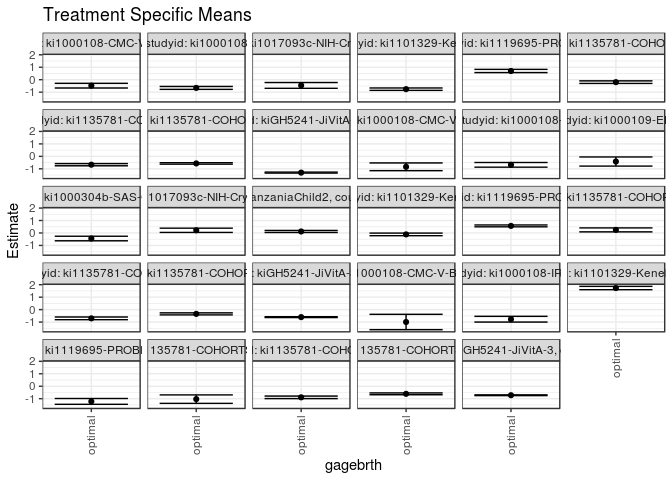

## Results Table

### Parameter: TSM

| agecat | studyid | country | intervention_level | baseline_level | estimate | ci_lower | ci_upper |
| --- | --- | --- | --- | --- | --- | --- | --- |
| Birth | ki1000108-CMC-V-BCS-2002 | INDIA | optimal | observed | -0.9947954 | -1.6098626 | -0.3797282 |
| Birth | ki1000108-IRC | INDIA | optimal | observed | -0.7699878 | -1.0002115 | -0.5397641 |
| Birth | ki1101329-Keneba | GAMBIA | optimal | observed | 1.7318941 | 1.5978303 | 1.8659579 |
| Birth | ki1119695-PROBIT | BELARUS | optimal | observed | -1.2173137 | -1.4496539 | -0.9849736 |
| Birth | ki1135781-COHORTS | GUATEMALA | optimal | observed | -1.0334422 | -1.3729733 | -0.6939110 |
| Birth | ki1135781-COHORTS | INDIA | optimal | observed | -0.8902422 | -0.9924117 | -0.7880726 |
| Birth | ki1135781-COHORTS | PHILIPPINES | optimal | observed | -0.6093621 | -0.6814647 | -0.5372596 |
| Birth | kiGH5241-JiVitA-3 | BANGLADESH | optimal | observed | -0.7209733 | -0.7536856 | -0.6882610 |
| 6 months | ki1000108-CMC-V-BCS-2002 | INDIA | optimal | observed | -0.8383938 | -1.1488750 | -0.5279126 |
| 6 months | ki1000108-IRC | INDIA | optimal | observed | -0.6821249 | -0.8693868 | -0.4948630 |
| 6 months | ki1000109-EE | PAKISTAN | optimal | observed | -0.4164721 | -0.7815005 | -0.0514438 |
| 6 months | ki1000304b-SAS-CompFeed | INDIA | optimal | observed | -0.4437723 | -0.6274118 | -0.2601328 |
| 6 months | ki1017093c-NIH-Crypto | BANGLADESH | optimal | observed | 0.2162659 | 0.0454246 | 0.3871072 |
| 6 months | ki1066203-TanzaniaChild2 | TANZANIA, UNITED REPUBLIC OF | optimal | observed | 0.1203949 | 0.0393605 | 0.2014293 |
| 6 months | ki1101329-Keneba | GAMBIA | optimal | observed | -0.1133599 | -0.2178375 | -0.0088824 |
| 6 months | ki1119695-PROBIT | BELARUS | optimal | observed | 0.5676077 | 0.4916393 | 0.6435761 |
| 6 months | ki1135781-COHORTS | GUATEMALA | optimal | observed | 0.2489116 | 0.0897806 | 0.4080427 |
| 6 months | ki1135781-COHORTS | INDIA | optimal | observed | -0.7016413 | -0.8109589 | -0.5923237 |
| 6 months | ki1135781-COHORTS | PHILIPPINES | optimal | observed | -0.3425120 | -0.4238613 | -0.2611627 |
| 6 months | kiGH5241-JiVitA-3 | BANGLADESH | optimal | observed | -0.6029071 | -0.6355836 | -0.5702305 |
| 24 months | ki1000108-CMC-V-BCS-2002 | INDIA | optimal | observed | -0.4773950 | -0.6648683 | -0.2899218 |
| 24 months | ki1000108-IRC | INDIA | optimal | observed | -0.6575513 | -0.7737980 | -0.5413045 |
| 24 months | ki1017093c-NIH-Crypto | BANGLADESH | optimal | observed | -0.4572887 | -0.6883190 | -0.2262585 |
| 24 months | ki1101329-Keneba | GAMBIA | optimal | observed | -0.7571450 | -0.8537843 | -0.6605057 |
| 24 months | ki1119695-PROBIT | BELARUS | optimal | observed | 0.7003702 | 0.5715368 | 0.8292037 |
| 24 months | ki1135781-COHORTS | GUATEMALA | optimal | observed | -0.1947326 | -0.2972359 | -0.0922294 |
| 24 months | ki1135781-COHORTS | INDIA | optimal | observed | -0.6699240 | -0.7585146 | -0.5813334 |
| 24 months | ki1135781-COHORTS | PHILIPPINES | optimal | observed | -0.5687708 | -0.6265123 | -0.5110293 |
| 24 months | kiGH5241-JiVitA-3 | BANGLADESH | optimal | observed | -1.3059518 | -1.3458942 | -1.2660095 |

### Parameter: E(Y)

| agecat | studyid | country | intervention_level | baseline_level | estimate | ci_lower | ci_upper |
| --- | --- | --- | --- | --- | --- | --- | --- |
| Birth | ki1000108-CMC-V-BCS-2002 | INDIA | observed | observed | -0.5788506 | -0.9164861 | -0.2412151 |
| Birth | ki1000108-IRC | INDIA | observed | observed | -1.0135366 | -1.2024730 | -0.8246002 |
| Birth | ki1101329-Keneba | GAMBIA | observed | observed | 1.6988437 | 1.6151574 | 1.7825300 |
| Birth | ki1119695-PROBIT | BELARUS | observed | observed | -1.1463469 | -1.3562674 | -0.9364264 |
| Birth | ki1135781-COHORTS | GUATEMALA | observed | observed | -1.0358042 | -1.1559527 | -0.9156557 |
| Birth | ki1135781-COHORTS | INDIA | observed | observed | -1.0098535 | -1.0741510 | -0.9455561 |
| Birth | ki1135781-COHORTS | PHILIPPINES | observed | observed | -0.7417745 | -0.7882773 | -0.6952718 |
| Birth | kiGH5241-JiVitA-3 | BANGLADESH | observed | observed | -0.7269895 | -0.7473033 | -0.7066757 |
| 6 months | ki1000108-CMC-V-BCS-2002 | INDIA | observed | observed | -0.4909778 | -0.6451612 | -0.3367945 |
| 6 months | ki1000108-IRC | INDIA | observed | observed | -0.5999270 | -0.7403711 | -0.4594828 |
| 6 months | ki1000109-EE | PAKISTAN | observed | observed | -0.7212766 | -0.8346857 | -0.6078675 |
| 6 months | ki1000304b-SAS-CompFeed | INDIA | observed | observed | -0.6667585 | -0.8065718 | -0.5269452 |
| 6 months | ki1017093c-NIH-Crypto | BANGLADESH | observed | observed | 0.0297622 | -0.0491685 | 0.1086930 |
| 6 months | ki1066203-TanzaniaChild2 | TANZANIA, UNITED REPUBLIC OF | observed | observed | 0.0815655 | 0.0271217 | 0.1360092 |
| 6 months | ki1101329-Keneba | GAMBIA | observed | observed | -0.1978234 | -0.2595091 | -0.1361378 |
| 6 months | ki1119695-PROBIT | BELARUS | observed | observed | 0.5789633 | 0.5190130 | 0.6389137 |
| 6 months | ki1135781-COHORTS | GUATEMALA | observed | observed | 0.1864566 | 0.1024304 | 0.2704827 |
| 6 months | ki1135781-COHORTS | INDIA | observed | observed | -0.6460976 | -0.7081436 | -0.5840516 |
| 6 months | ki1135781-COHORTS | PHILIPPINES | observed | observed | -0.2920968 | -0.3336448 | -0.2505489 |
| 6 months | kiGH5241-JiVitA-3 | BANGLADESH | observed | observed | -0.6084556 | -0.6302315 | -0.5866796 |
| 24 months | ki1000108-CMC-V-BCS-2002 | INDIA | observed | observed | -0.5369143 | -0.6415957 | -0.4322329 |
| 24 months | ki1000108-IRC | INDIA | observed | observed | -0.7414957 | -0.8350522 | -0.6479392 |
| 24 months | ki1017093c-NIH-Crypto | BANGLADESH | observed | observed | -0.6103502 | -0.7050157 | -0.5156847 |
| 24 months | ki1101329-Keneba | GAMBIA | observed | observed | -0.7953404 | -0.8531640 | -0.7375168 |
| 24 months | ki1119695-PROBIT | BELARUS | observed | observed | 0.6863435 | 0.5745700 | 0.7981170 |
| 24 months | ki1135781-COHORTS | GUATEMALA | observed | observed | -0.2397001 | -0.3082360 | -0.1711643 |
| 24 months | ki1135781-COHORTS | INDIA | observed | observed | -0.5717874 | -0.6260792 | -0.5174955 |
| 24 months | ki1135781-COHORTS | PHILIPPINES | observed | observed | -0.6079283 | -0.6449298 | -0.5709269 |
| 24 months | kiGH5241-JiVitA-3 | BANGLADESH | observed | observed | -1.3045023 | -1.3312349 | -1.2777698 |

### Parameter: PAR

| agecat | studyid | country | intervention_level | baseline_level | estimate | ci_lower | ci_upper |
| --- | --- | --- | --- | --- | --- | --- | --- |
| Birth | ki1000108-CMC-V-BCS-2002 | INDIA | optimal | observed | 0.4159448 | -0.0289376 | 0.8608272 |
| Birth | ki1000108-IRC | INDIA | optimal | observed | -0.2435488 | -0.3875808 | -0.0995168 |
| Birth | ki1101329-Keneba | GAMBIA | optimal | observed | -0.0330504 | -0.1480791 | 0.0819783 |
| Birth | ki1119695-PROBIT | BELARUS | optimal | observed | 0.0709668 | -0.0119594 | 0.1538930 |
| Birth | ki1135781-COHORTS | GUATEMALA | optimal | observed | -0.0023620 | -0.3125800 | 0.3078560 |
| Birth | ki1135781-COHORTS | INDIA | optimal | observed | -0.1196114 | -0.1948005 | -0.0444223 |
| Birth | ki1135781-COHORTS | PHILIPPINES | optimal | observed | -0.1324124 | -0.1890397 | -0.0757852 |
| Birth | kiGH5241-JiVitA-3 | BANGLADESH | optimal | observed | -0.0060162 | -0.0302003 | 0.0181680 |
| 6 months | ki1000108-CMC-V-BCS-2002 | INDIA | optimal | observed | 0.3474160 | 0.0736116 | 0.6212203 |
| 6 months | ki1000108-IRC | INDIA | optimal | observed | 0.0821980 | -0.0515669 | 0.2159628 |
| 6 months | ki1000109-EE | PAKISTAN | optimal | observed | -0.3048045 | -0.6649131 | 0.0553041 |
| 6 months | ki1000304b-SAS-CompFeed | INDIA | optimal | observed | -0.2229862 | -0.4606275 | 0.0146550 |
| 6 months | ki1017093c-NIH-Crypto | BANGLADESH | optimal | observed | -0.1865037 | -0.3377216 | -0.0352858 |
| 6 months | ki1066203-TanzaniaChild2 | TANZANIA, UNITED REPUBLIC OF | optimal | observed | -0.0388295 | -0.0995248 | 0.0218659 |
| 6 months | ki1101329-Keneba | GAMBIA | optimal | observed | -0.0844635 | -0.1669961 | -0.0019309 |
| 6 months | ki1119695-PROBIT | BELARUS | optimal | observed | 0.0113556 | -0.0382972 | 0.0610084 |
| 6 months | ki1135781-COHORTS | GUATEMALA | optimal | observed | -0.0624551 | -0.1959457 | 0.0710356 |
| 6 months | ki1135781-COHORTS | INDIA | optimal | observed | 0.0555438 | -0.0396617 | 0.1507493 |
| 6 months | ki1135781-COHORTS | PHILIPPINES | optimal | observed | 0.0504152 | -0.0175225 | 0.1183528 |
| 6 months | kiGH5241-JiVitA-3 | BANGLADESH | optimal | observed | -0.0055485 | -0.0291299 | 0.0180329 |
| 24 months | ki1000108-CMC-V-BCS-2002 | INDIA | optimal | observed | -0.0595193 | -0.2294598 | 0.1104212 |
| 24 months | ki1000108-IRC | INDIA | optimal | observed | -0.0839445 | -0.1552279 | -0.0126610 |
| 24 months | ki1017093c-NIH-Crypto | BANGLADESH | optimal | observed | -0.1530614 | -0.3683976 | 0.0622747 |
| 24 months | ki1101329-Keneba | GAMBIA | optimal | observed | -0.0381954 | -0.1142622 | 0.0378715 |
| 24 months | ki1119695-PROBIT | BELARUS | optimal | observed | -0.0140267 | -0.0688511 | 0.0407976 |
| 24 months | ki1135781-COHORTS | GUATEMALA | optimal | observed | -0.0449675 | -0.1201536 | 0.0302186 |
| 24 months | ki1135781-COHORTS | INDIA | optimal | observed | 0.0981367 | 0.0250884 | 0.1711850 |
| 24 months | ki1135781-COHORTS | PHILIPPINES | optimal | observed | -0.0391575 | -0.0853641 | 0.0070491 |
| 24 months | kiGH5241-JiVitA-3 | BANGLADESH | optimal | observed | 0.0014495 | -0.0285262 | 0.0314253 |